# Eric_Hirsch_605_Discussion_11

Eric Hirsch

11/2/2021

```r
library(openintro)
library(tinytex)
library(tidyverse)
library(magrittr)
library(RODBC)
library(gridExtra)
library(psych)
library(moments)
library(kableExtra)
```

### A Problemmatic Flight Arrival Delay Calculator

Your colleagues do a lot of flying and you are tasked with developing a model so that you can predict any flight arrival delay based on a departure delay. That way they can call the delay in before they get on the plane.

Using the nycflights database of 30,000 flights from New York airports, you decide to run a regression on arrival delay and departure delay. First you perform a scatterplot and it looks good:

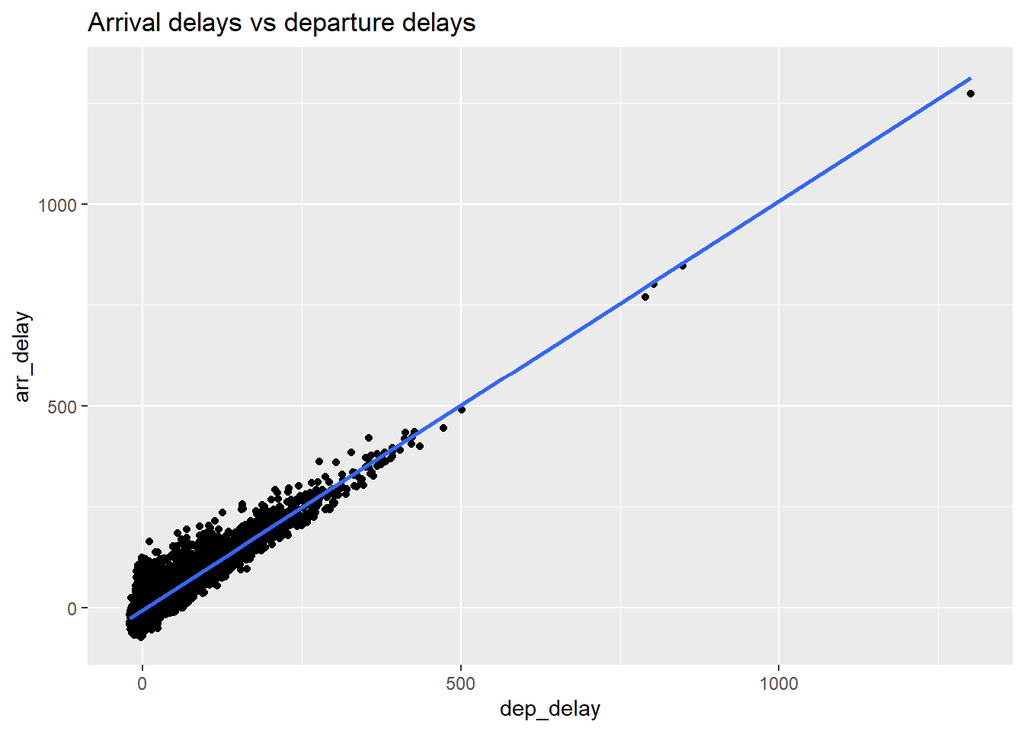

```r
ggplot(nycflights, aes(dep_delay, arr_delay)) +
  geom_point() +
  stat_smooth(method = "lm") +
  ggtitle("Arrival delays vs departure delays")
```

Then you run the regression. Not surprisingly, arrival and departure delay shows a very strong correlation, with an r-squared of .84.

```r
m <- lm(arr_delay ~ dep_delay, data = nycflights)
summary(m)
```

```
##
## Call:
## lm(formula = arr_delay ~ dep_delay, data = nycflights)
##
## Residuals:
##     Min      1Q  Median      3Q     Max
## -70.544 -11.138  -1.316   8.836 158.627
##
## Coefficients:
##              Estimate Std. Error t value Pr(>|t|)
## (Intercept) -5.770652   0.103834  -55.58   <2e-16 ***
## dep_delay    1.013090   0.002451  413.27   <2e-16 ***
## ---
## Signif. codes:  0 '***' 0.001 '**' 0.01 '*' 0.05 '.' 0.1 ' ' 1
##
## Residual standard error: 17.92 on 32733 degrees of freedom
## Multiple R-squared:  0.8392, Adjusted R-squared:  0.8392
## F-statistic: 1.708e+05 on 1 and 32733 DF,  p-value: < 2.2e-16
```

The coefficients line up nicely to give you a simple rule of thumb which you pass on to your manager - *arrival delays are typically the same as departure delays minus 5 minutes of in-air catch-up time.*

**A week later you’re in trouble.**

Your colleagues are reporting lots of small departure delays that don’t seem to relate to their arrival delay at all. And lots of long arrival delays even thought the plane left on time. Your calculator only seems reliable when there is a long departure day, resulting in a long arrival delay. What happened?

You decide to remove outliers.

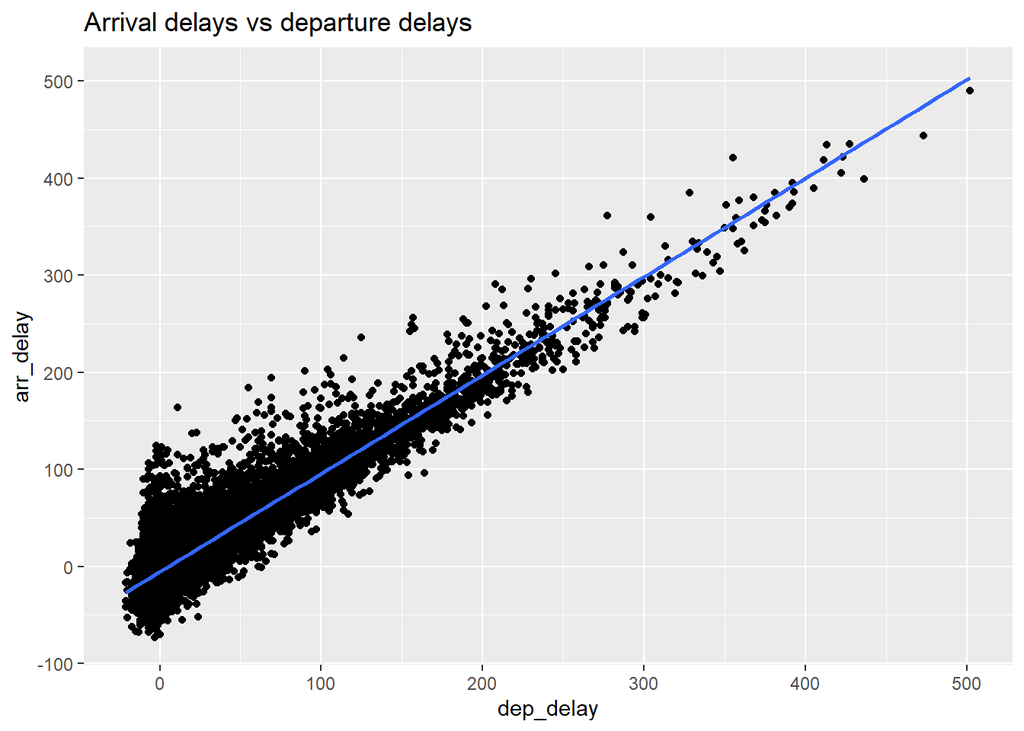

```r
dfFlights <-nycflights %>%
  filter(dep_delay<550)

ggplot(dfFlights, aes(dep_delay, arr_delay)) +
  geom_point() +
  stat_smooth(method = "lm") +
  ggtitle("Arrival delays vs departure delays")
```

```r
m1 <- lm(arr_delay ~ dep_delay, data = dfFlights)
summary(m1)
```

```
##
## Call:
## lm(formula = arr_delay ~ dep_delay, data = dfFlights)
##
## Residuals:
##     Min      1Q  Median      3Q     Max
## -70.565 -11.122  -1.329   8.863 158.627
##
## Coefficients:
##              Estimate Std. Error t value Pr(>|t|)
## (Intercept) -5.789059   0.104081  -55.62   <2e-16 ***
## dep_delay    1.014744   0.002538  399.83   <2e-16 ***
## ---
## Signif. codes:  0 '***' 0.001 '**' 0.01 '*' 0.05 '.' 0.1 ' ' 1
##
## Residual standard error: 17.92 on 32729 degrees of freedom
## Multiple R-squared:  0.8301, Adjusted R-squared:  0.8301
## F-statistic: 1.599e+05 on 1 and 32729 DF,  p-value: < 2.2e-16
```

But the results are almost exactly the same.

You look at histograms of the two variables, and find something surprising - most flights arrive or leave a little early:

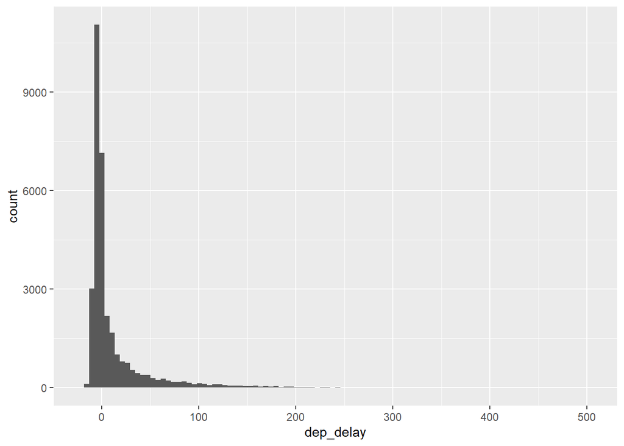

```r
ggplot(dfFlights, aes(dep_delay)) +
  geom_histogram(bins=100)
```

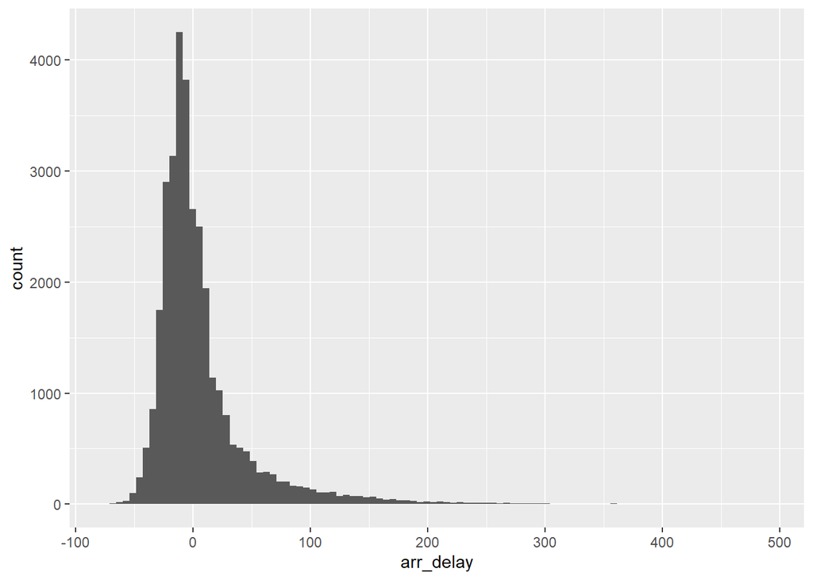

```r
ggplot(dfFlights, aes(arr_delay)) +
  geom_histogram(bins=100)
```

You reason that flights that arrive early or on time might be a different breed of flight altogether from those that arrive late, so you eliminate them from the analysis:

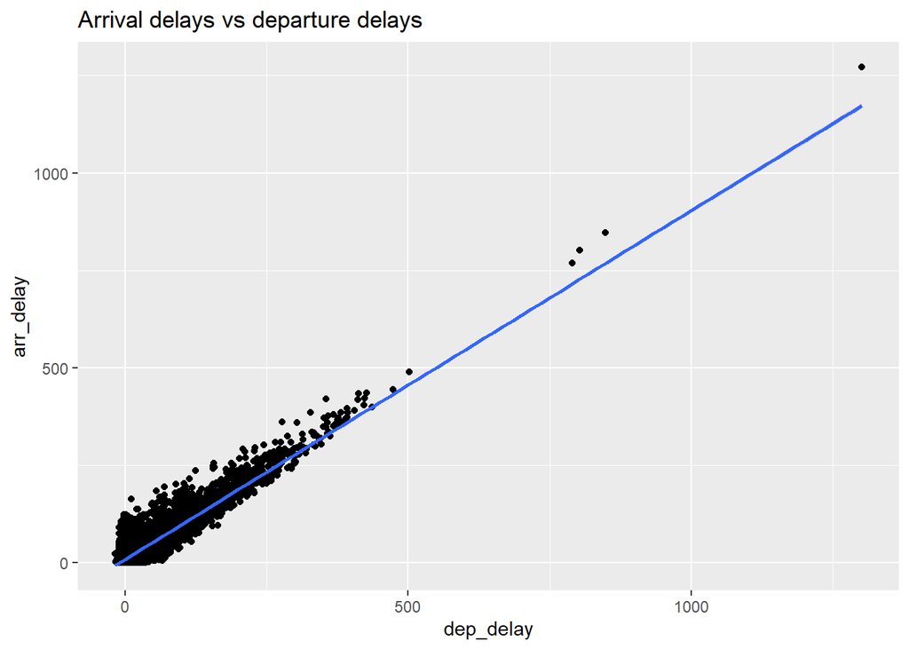

```r
dfFlights2 <-nycflights %>%
  filter(arr_delay>0)

ggplot(dfFlights2, aes(dep_delay, arr_delay)) +
  geom_point() +
  stat_smooth(method = "lm") +
  ggtitle("Arrival delays vs departure delays")
```

```r
m1 <- lm(arr_delay ~ dep_delay, data = dfFlights)
summary(m1)
```

```
##
## Call:
## lm(formula = arr_delay ~ dep_delay, data = dfFlights)
##
## Residuals:
##     Min      1Q  Median      3Q     Max
## -70.565 -11.122  -1.329   8.863 158.627
##
## Coefficients:
##              Estimate Std. Error t value Pr(>|t|)
## (Intercept) -5.789059   0.104081  -55.62   <2e-16 ***
## dep_delay    1.014744   0.002538  399.83   <2e-16 ***
## ---
## Signif. codes:  0 '***' 0.001 '**' 0.01 '*' 0.05 '.' 0.1 ' ' 1
##
## Residual standard error: 17.92 on 32729 degrees of freedom
## Multiple R-squared:  0.8301, Adjusted R-squared:  0.8301
## F-statistic: 1.599e+05 on 1 and 32729 DF,  p-value: < 2.2e-16
```

Since the model seems more precise at higher levels of departure delay, the place to look is the residuals. A residual analysis shows clearly what the problem is:

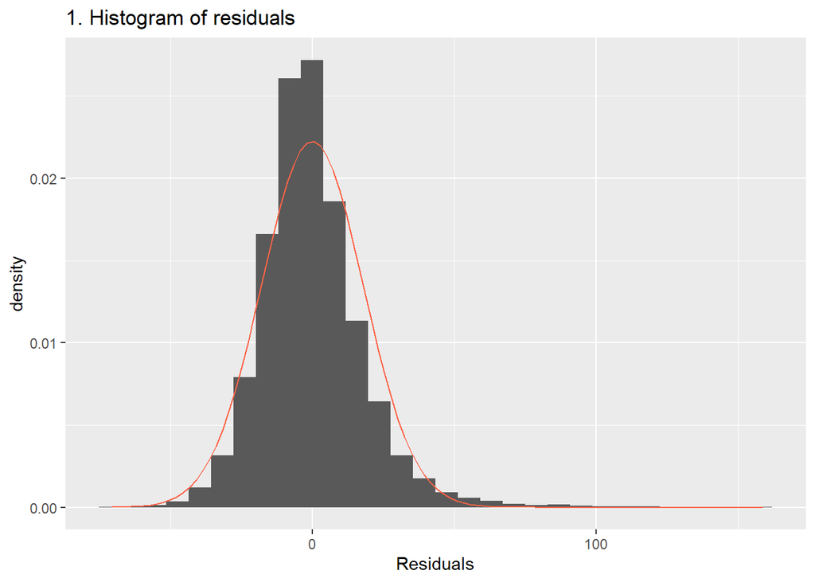

```r
dmean <- 0
dse <- summary(m1)$sigma

ggplot(data = m1, aes(x = .resid)) +
  geom_histogram(aes(y = ..density..)) +
  xlab("Residuals") +
  ggtitle("1. Histogram of residuals") +
  stat_function(fun = dnorm, args = c(mean = dmean, sd = dse), col = "tomato")
```

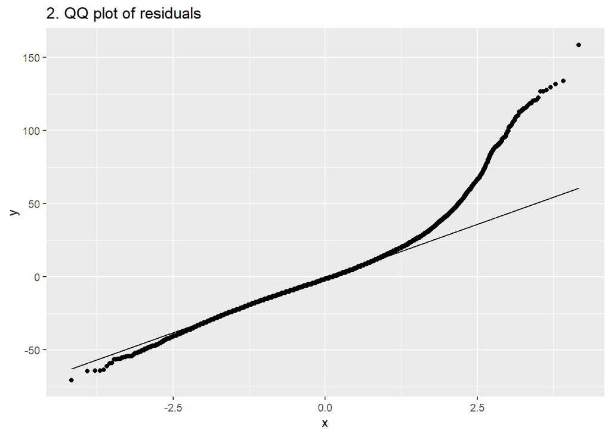

```r
ggplot(data = m1, aes(sample = .resid)) +
  stat_qq() +
  stat_qq_line() +
  ggtitle("2. QQ plot of residuals")
```

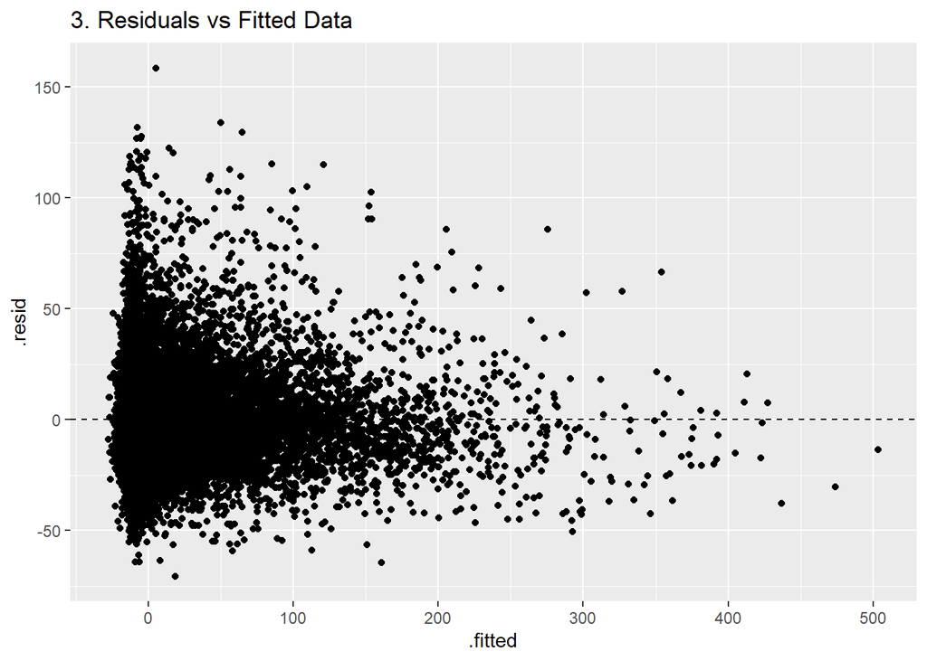

```r
ggplot(data=m1, aes(
    x = .fitted,
    y = .resid
  )) +
  geom_jitter() +
    geom_hline(yintercept = 0, linetype = "dashed") +
  ggtitle("3. Residuals vs Fitted Data")
```

We can verify that the model does poorly for short delays by running the analysis for departure delays equal to or below 15 minutes:

```r
dfShort <- dfFlights %>%
  filter(abs(dep_delay)<=15)

m2 <- lm(arr_delay ~ dep_delay, data = dfShort)
summary(m2)
```

```
##
## Call:
## lm(formula = arr_delay ~ dep_delay, data = dfShort)
##
## Residuals:
##     Min      1Q  Median      3Q     Max
## -64.042 -10.298  -1.138   8.958 158.606
##
## Coefficients:
##             Estimate Std. Error t value Pr(>|t|)
## (Intercept) -5.95817    0.11314  -52.66   <2e-16 ***
## dep_delay    1.03201    0.01907   54.12   <2e-16 ***
## ---
## Signif. codes:  0 '***' 0.001 '**' 0.01 '*' 0.05 '.' 0.1 ' ' 1
##
## Residual standard error: 16.97 on 25597 degrees of freedom
## Multiple R-squared:  0.1027, Adjusted R-squared:  0.1026
## F-statistic:  2929 on 1 and 25597 DF,  p-value: < 2.2e-16
```

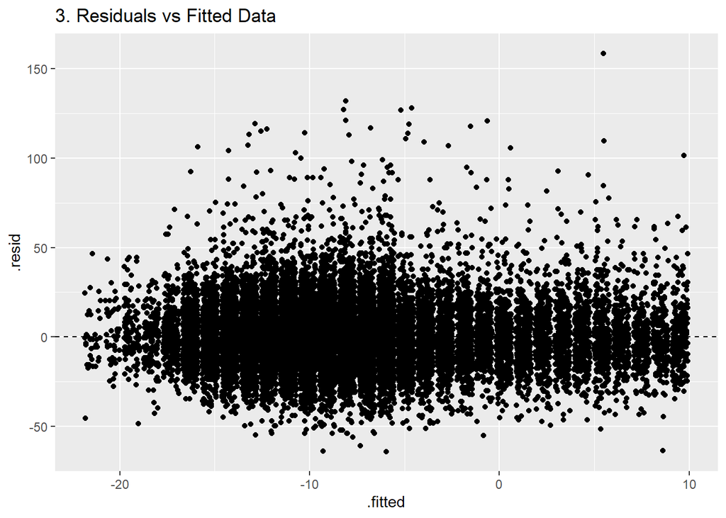

```r
ggplot(data=m2, aes(
    x = .fitted,
    y = .resid
  )) +
  geom_jitter() +
    geom_hline(yintercept = 0, linetype = "dashed") +
  ggtitle("3. Residuals vs Fitted Data")
```

The R squared has dropped to .10. At this level of departure delay the data is homoskedastic.

### Conclusion

Diagnostic plots tell you not only that there may be problems with your model, but how they may manifest. It would have been best to check them first before delivering the model.